# Power Analysis for Three-level Longitudinal Models with Missing Data

Kristoffer Magnusson

2018-08-14

This vignette shows how to setup and calculate power for three-level models with nesting in one or both of the treatment arms.

# Three-level models

Currently, `powerlmm` support three-level models that are fully nested or partially nested; crossed designs are not yet supported.

## Model formulation

In standard multilevel notation the fully *nested* three-level linear mixed-effects model is
$$\begin{align}
\text{Level 1}& \notag\\\
Y_{ijk} &= \beta_{0jk} + \beta_{1jk}t_{ijk} + R_{ijk}\\\
\text{Level 2}& \notag\\\
\beta_{0jk} &= \gamma_{00k} + U_{0jk} \\\
\beta_{1jk} &= \gamma_{10k} + U_{1jk} \\\
\text{Level 3}& \notag\\\
\gamma_{00k} &= \delta_{000} + \delta_{001} TX_k + V_{0k} \\\
\gamma_{10k} &= \delta_{100} + \delta_{101} TX_k + V_{1k} \\\
\end{align}$$
with,
$$\begin{equation}
\begin{pmatrix}
U_{0j} \\\
U_{1j}
\end{pmatrix}
\sim\mathcal{N}
\left(
\begin{matrix}
0 &\\\
0
\end{matrix}
,
\begin{matrix}
\sigma_{u_0}^2 & \sigma_{u_{01}} \\\
\sigma_{u_{01}} & \sigma_{u_{1}}^2
\end{matrix}
\right)
,
\end{equation}$$
and,
$$\begin{equation}
\begin{pmatrix}
V_{0k} \\\
V_{1k}
\end{pmatrix}
\sim\mathcal{N}
\left(
\begin{matrix}
0 &\\\
0
\end{matrix}
,
\begin{matrix}
\sigma_{v_0}^2 & \sigma_{v_{01}} \\\
\sigma_{v_{01}} & \sigma_{v_{1}}^2
\end{matrix}
\right)
,
\end{equation}$$
and
$$\begin{equation}
R_{ijk} \sim\mathcal{N}(0, ~\sigma_e^2)
\end{equation}$$

The corresponding arguments in `study_parameters` are

| parameter | `study_parameters()-`argument |
| --- | --- |
| $\delta_{000}$ | `fixed_intercept` |
| $\delta_{001}$ | NA; assumed to be 0 |
| $\delta_{100}$ | `fixed_slope` |
| $\delta_{101}$ | calculated from `effect_size` |
| $\sigma_{u_0}$ | `sigma_subject_intercept` |
| $\sigma_{u_1}$ | `sigma_subject_slope` |
| $\sigma_{u_{01}}$ | calculated from `cor_subject` |
| $\sigma_{v_0}$ | `sigma_cluster_intercept` |
| $\sigma_{v_1}$ | `sigma_cluster_slope` |
| $\sigma_{v_{01}}$ | calculated from `cor_cluster` |
| $\sigma_e$ | `sigma_error` |

## Standardized and unstandardized formulation

If you are only interested in power of a model, then it is not necessary to define all parameters in the model. For a three-level model power depends on `n1`, `n2`, `n3`, the ratio of subject-level random slope variance to the within-subject error variance (`var_ratio`), and the amount of random slope variance at the third-level (`icc_slope`). Depending on how the effect size in standardized, other paramaters also influence power. If the pretest SD is used as the standardizer, power is influenced by the ratio of the intercept variances to the residual variance (i.e., `icc_pre_subjects`), since the standardization of Cohen’s *d* depends on those parameters.

The relative standardized inputs are calculated in the following way.

| Standardized | Calculation |
| --- | --- |
| `icc_pre_subjects` | $(\sigma_{u_0}^2 + \sigma_{v_0}^2)/(\sigma_{u_0}^2 + \sigma_{v_0}^2 + \sigma_e^2)$ |
| `icc_pre_clusters` | $\sigma_{v_0}^2/(\sigma_{u_0}^2 + \sigma_{v_0}^2 + \sigma_e^2)$ |
| `icc_slope` | $\sigma_{v_1}^2/(\sigma_{u_1}^2 + \sigma_{v_1}^2)$ |
| `var_ratio` | $(\sigma_{u_1}^2 + \sigma_{v_1}^2)/\sigma_e^2$ |

Using the argument names in `study_parameters`, the standardized inputs are calculated in the following way.

| Standardized | Calculation |
| --- | --- |
| `icc_pre_subjects` | `(sigma_subject_intercept^2 + sigma_cluster_intercept^2)/(sigma_subject_intercept^2 + sigma_cluster_intercept^2 + sigma_error^2)` |
| `icc_pre_clusters` | `sigma_cluster_intercept^2/(sigma_subject_intercept^2 + sigma_cluster_intercept^2 + sigma_error^2)` |
| `icc_slope` | `sigma_custer_slope^2/(sigma_cluster_slope^2 + sigma_subject_slope^2)` |
| `var_ratio` | `(sigma_subject_slope^2 + sigma_custer_slope^2)/sigma_error^2` |

### Effect sizes

The argument `effect_size` either accepts the raw difference between the groups at posttest, or a standardized effect size by passing the `cohend(...)` function. Cohen’s *d* can be calculated using either the pretest, posttest, or random slope SD as the standardizer (denominator). See `?cohend` for options.

For standardized effect sizes that use either the pretest or posttest SD, the effect size refers to the standardized difference between the groups at posttest,
$$\delta_{101} = \frac{\text{ES} \times \sigma}{T_{end}}.$$
Where the standardizer $\sigma$ is one of the following standardizers (based either on the treatment or control groups variance components):

- pretest SD,
  $$\sigma_{pre} = \sqrt{\sigma_{u0}^2 + \sigma_{v0}^2 + \sigma_{e}^2}.$$
- posttest SD,
  $$\sigma_{post} = \sqrt{\sigma_{u0}^2 + 2T_{end}\sigma_{u01} + T_{end}^2\sigma_{u1}^2 + \sigma_{v0}^2+2T_{end}\sigma_{v01}+T_{end}^2\sigma_{v1}^2 + \sigma_{e}^2}.$$

If the random slope SD (cf. Raudenbush and Xiao-Feng (2001)) is used as the standardizer, the ES now indicate the difference per unit of time,
$$\delta_{101} = \text{ES} \times \sigma_{slopes},$$
where the standardizer is,
$$\sigma_{slopes} = \sqrt{\sigma_{u1}^2 + \sigma_{v1}^2}.$$

# Study setup

This example will show how to calculate power for the `time:treatment`-interaction. We assume that the two treatment arms will differ by a Cohen’s *d* of 0.8 at posttest. The treatment period is 11 weeks with weekly measures, and each treatment group has 4 therapists that each treat 10 participants. We are expecting that 5 % of the total slope variance will be at the therapist level, and there will be a moderate amount of heterogeneity in change over time (var_ratio = 0.02), Lastly, 50 % of the baseline variance is at the subject level, and `icc_pre_cluster` is set to 0 since we are randomizing subjects to clusters, and hence there should be no therapist effect at baseline.

```r
p <- study_parameters(n1 = 11,
                      n2 = 10,
                      n3 = 4,
                      icc_pre_subject = 0.5,
                      icc_pre_cluster = 0,
                      icc_slope = 0.05,
                      var_ratio = 0.02,
                      effect_size = cohend(-0.8,
                                           standardizer = "pretest_SD"))
p
```

```
##
##      Study setup (three-level)
##
##               n1 = 11
##               n2 = 10 x 4 (treatment)
##                    10 x 4 (control)
##               n3 = 4      (treatment)
##                    4      (control)
##                    8      (total)
##          total_n = 40     (treatment)
##                    40     (control)
##                    80     (total)
##          dropout = No missing data
## icc_pre_subjects = 0.5
## icc_pre_clusters = 0
##        icc_slope = 0.05
##        var_ratio = 0.02
##      effect_size = -0.8 (Cohen's d [SD: pretest_SD])
```

## Power

To calculate power for the study, we use the `get_power`-method using the object created with `study_parameters`.

```r
get_power(p)
```

```
##
##      Power Analyis for Longitudinal Linear Mixed-Effects Models (three-level)
##                   with missing data and unbalanced designs
##
##               n1 = 11
##               n2 = 10 x 4 (treatment)
##                    10 x 4 (control)
##               n3 = 4      (treatment)
##                    4      (control)
##                    8      (total)
##          total_n = 40     (control)
##                    40     (treatment)
##                    80     (total)
##          dropout = No missing data
## icc_pre_subjects = 0.5
## icc_pre_clusters = 0
##        icc_slope = 0.05
##        var_ratio = 0.02
##      effect_size = -0.8 (Cohen's d [SD: pretest_SD])
##               df = 6
##            alpha = 0.05
##            power = 58%
```

### Degrees of freedom

By default `get_power` uses the between-cluster degrees of freedom for three-level models. However, unless sample sizes are large it is probably recommended to use `df = "satterthwaite"`.

## Understanding the model

Several helper functions are available to help you explore the implications of the model’s parameters. For instance, we can calculate the variance partitioning coefficients (VPC), to see how the proportion of variance at each level change over time.

```r
get_VPC(p)
```

```
## # Percentage (%) of total variance at each level and time point
##    time between_clusters between_subjects within_subjects tot_var
## 1     0             0.00               50              50       0
## 2     1             0.05               50              50       1
## 3     2             0.19               52              48       4
## 4     3             0.41               54              46       9
## 5     4             0.69               56              43      16
## 6     5             1.00               59              40      25
## 7     6             1.32               62              37      36
## 8     7             1.64               65              34      49
## 9     8             1.95               68              30      64
## 10    9             2.24               70              28      81
## 11   10             2.50               72              25     100
```

`between_clusters/100` corresponds to the ICC at level 3 per time point, i.e. the correlation between two subjects belonging to the same cluster. `tot_var` gives the percentage change in variance per time point, compared to the baseline total variance, i.e. at the last time point the total variance is 100 % larger than at baseline. If you want to see the correlation between time points, you can use `get_correlation_matrix(p)`

```r
get_correlation_matrix(p)
```

```
##       0    1    2    3    4    5    6    7    8    9   10
## 0  1.00 0.50 0.49 0.48 0.46 0.45 0.43 0.41 0.39 0.37 0.35
## 1  0.50 1.00 0.51 0.51 0.50 0.49 0.48 0.46 0.45 0.44 0.42
## 2  0.49 0.51 1.00 0.53 0.53 0.53 0.52 0.51 0.51 0.50 0.49
## 3  0.48 0.51 0.53 1.00 0.55 0.56 0.56 0.56 0.55 0.55 0.54
## 4  0.46 0.50 0.53 0.55 1.00 0.58 0.59 0.59 0.59 0.59 0.59
## 5  0.45 0.49 0.53 0.56 0.58 1.00 0.61 0.62 0.63 0.63 0.63
## 6  0.43 0.48 0.52 0.56 0.59 0.61 1.00 0.65 0.66 0.66 0.67
## 7  0.41 0.46 0.51 0.56 0.59 0.62 0.65 1.00 0.68 0.69 0.70
## 8  0.39 0.45 0.51 0.55 0.59 0.63 0.66 0.68 1.00 0.71 0.72
## 9  0.37 0.44 0.50 0.55 0.59 0.63 0.66 0.69 0.71 1.00 0.74
## 10 0.35 0.42 0.49 0.54 0.59 0.63 0.67 0.70 0.72 0.74 1.00
```

Lastly, a longitudinal study with random slopes implies that the standard deviation per time point follows a quadratic function over time. You can get the model implied standard deviations per time point using `get_sds`.

```r
get_sds(p)
```

```
##    time SD_with_random_slopes SD_no_cluster_random_slope
## 1     0                    14                         14
## 2     1                    14                         14
## 3     2                    14                         14
## 4     3                    15                         15
## 5     4                    15                         15
## 6     5                    16                         16
## 7     6                    16                         16
## 8     7                    17                         17
## 9     8                    18                         18
## 10    9                    19                         19
## 11   10                    20                         20
##    SD_no_random_slopes
## 1                   14
## 2                   14
## 3                   14
## 4                   14
## 5                   14
## 6                   14
## 7                   14
## 8                   14
## 9                   14
## 10                  14
## 11                  14
```

Since, we defined our study using only standardized inputs, `get_sds` prints the SDs for a default `sigma_error` = 10. At week 10 the SDs will be 20/14 = 1.4 times larger than at baseline. If we used raw values for all parameters defined with `study_parameters`, then these SDs would be the actual model implied standard deviations per time points. Its useful to check that these values make sense.

# Compare different values

In a three-level design with random slopes, power depends heavily on the amount of clusters, and `icc_slope` and `var_ratio`. The function `get_power_table` is helpful when you want to compare the effect of up to 3 different parameters.

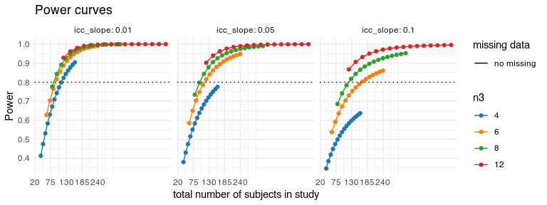

```r
library(ggplot2)
x <- get_power_table(p, n2 = 5:20, n3 = c(4, 6, 8, 12), icc_slope = c(0.01, 0.05, 0.1))
plot(x) + scale_x_continuous(breaks = seq(20, 240, length.out = 5))
```

The plot shows clearly that including more clusters yields higher power for the same amount of total participants.

# Unbalanced designs

It is possible to define different cluster size both within a treatment and between treatment groups using the `per_treatment` function. Here’s an example of how to have more clusters in the treatment group.

```r
p <- study_parameters(n1 = 11,
                      n2 = 10,
                      n3 = per_treatment(control = 2,
                                         treatment = 10),
                      icc_pre_subject = 0.5,
                      icc_pre_cluster = 0,
                      icc_slope = 0.05,
                      var_ratio = 0.02,
                      effect_size = cohend(-0.8,
                                           standardizer = "pretest_SD")
                      )
p
```

```
##
##      Study setup (three-level)
##
##               n1 = 11
##               n2 = 10 x 10 (treatment)
##                    10 x 2  (control)
##               n3 = 10      (treatment)
##                    2       (control)
##                    12      (total)
##          total_n = 100     (treatment)
##                    20      (control)
##                    120     (total)
##          dropout = No missing data
## icc_pre_subjects = 0.5
## icc_pre_clusters = 0
##        icc_slope = 0.05
##        var_ratio = 0.02
##      effect_size = -0.8 (Cohen's d [SD: pretest_SD])
```

Since both treatment arms have the same amount of participants per cluster (`n2`), the treatment arm will have much more participants. However, we can also use `per_treatment` to set the number of participants per cluster to be different in the two treatment arms.

```r
p <- study_parameters(n1 = 11,
                      n2 = per_treatment(control = 10,
                                         treatment = 2),
                      n3 = per_treatment(control = 2,
                                         treatment = 10),
                      icc_pre_subject = 0.5,
                      icc_pre_cluster = 0,
                      icc_slope = 0.05,
                      var_ratio = 0.02,
                      effect_size = cohend(-0.8,
                                           standardizer = "pretest_SD"))
p
```

```
##
##      Study setup (three-level)
##
##               n1 = 11
##               n2 = 2 x 10 (treatment)
##                    10 x 2 (control)
##               n3 = 10     (treatment)
##                    2      (control)
##                    12     (total)
##          total_n = 20     (treatment)
##                    20     (control)
##                    40     (total)
##          dropout = No missing data
## icc_pre_subjects = 0.5
## icc_pre_clusters = 0
##        icc_slope = 0.05
##        var_ratio = 0.02
##      effect_size = -0.8 (Cohen's d [SD: pretest_SD])
```

In this example, both treatment arms have 20 participants in total, but different amount of clusters, e.g. therapists.

## Different cluster sizes within a treatment arm

Lastly, we can use the `unequal_clusters`-function to define clusters of varying sizes within a treatment arm.

```r
p <- study_parameters(n1 = 11,
                      n2 = unequal_clusters(2, 5, 10, 30),
                      icc_pre_subject = 0.5,
                      icc_pre_cluster = 0,
                      icc_slope = 0.05,
                      var_ratio = 0.02,
                      effect_size = cohend(-0.8,
                                           standardizer = "pretest_SD"))
p
```

```
##
##      Study setup (three-level)
##
##               n1 = 11
##               n2 = 2, 5, 10, 30 (treatment)
##                    2, 5, 10, 30 (control)
##               n3 = 4            (treatment)
##                    4            (control)
##                    8            (total)
##          total_n = 47           (treatment)
##                    47           (control)
##                    94           (total)
##          dropout = No missing data
## icc_pre_subjects = 0.5
## icc_pre_clusters = 0
##        icc_slope = 0.05
##        var_ratio = 0.02
##      effect_size = -0.8 (Cohen's d [SD: pretest_SD])
```

Here we have setup a study that have 4 therapists (clusters) per treatment arm, but each therapist are assigned a different amount of subjects (2, 5, 10 and 30 clients, respectively). When we use `unequal_clusters` we don’t need to specify `n3`. Moreover, `unequal_clusters` can be combined with `per_treatment`, like so:

```r
n2 <- per_treatment(control = unequal_clusters(5, 10, 15),
                    treatment = unequal_clusters(2, 3, 5, 5, 10, 15, 25))

p <- study_parameters(n1 = 11,
                      n2 = n2,
                      icc_pre_subject = 0.5,
                      icc_pre_cluster = 0,
                      icc_slope = 0.05,
                      var_ratio = 0.02,
                      effect_size = cohend(-0.8,
                                           standardizer = "pretest_SD"))
p
```

```
##
##      Study setup (three-level)
##
##               n1 = 11
##               n2 = 2, 3, 5, 5, 10, 15, 25 (treatment)
##                    5, 10, 15              (control)
##               n3 = 7                      (treatment)
##                    3                      (control)
##                    10                     (total)
##          total_n = 65                     (treatment)
##                    30                     (control)
##                    95                     (total)
##          dropout = No missing data
## icc_pre_subjects = 0.5
## icc_pre_clusters = 0
##        icc_slope = 0.05
##        var_ratio = 0.02
##      effect_size = -0.8 (Cohen's d [SD: pretest_SD])
```

## Random cluster sizes

Instead of exactly specifying the numbers of subjects per cluster, we can treat it as a random variable and instead specify a probability distribution. This is probably preferable, unless it is exactly known how patients will be allocated. Since each power calculation will be based on a different realization of cluster sizes, it is wise to repeatedly calculate power for repeated realization from the distribution of cluster sizes. This is done automatically by adding the argument `R`, the output is then show the expected values by averaging over the realizations. Here’s an example using the Poisson distribution.

```r
n2 <- unequal_clusters(func = rpois(n = 5, lambda = 5))

p <- study_parameters(n1 = 3,
                      n2 = n2,
                      icc_pre_subject = 0.5,
                      icc_pre_cluster = 0,
                      icc_slope = 0.05,
                      var_ratio = 0.02,
                      effect_size = cohend(-0.8,
                                           standardizer = "pretest_SD"))
get_power(p, R = 10, progress = FALSE)
```

```
##
##      Power Analyis for Longitudinal Linear Mixed-Effects Models (three-level)
##                   with missing data and unbalanced designs
##
##               n1 = 3
##               n2 = rpois(n = 5, lambda = 5) (treatment)
##                    -                        (control)
##               n3 = 5                        (treatment)
##                    5                        (control)
##                    10                       (total)
##          total_n = 22.8                     (control)
##                    22.8                     (treatment)
##                    45.6                     (total)
##          dropout = No missing data
## icc_pre_subjects = 0.5
## icc_pre_clusters = 0
##        icc_slope = 0.05
##        var_ratio = 0.02
##      effect_size = -0.8 (Cohen's d [SD: pretest_SD])
##               df = 8
##            alpha = 0.05
##            power = 63% (MCSE: 3%)
##
## NOTE: n2 is randomly sampled. Values are the mean from R = 10 realizations.
```

N.B., in this case cluster sizes are *not* sampled independently for each treatment group, i.e. both groups will have exactly the same cluster imbalance. To sample each group independently, either from the same or from a different distribution, use `per_treatment`.

```r
# sample cluster sizes in each treatment group independently
# but from the same distribution
func <- unequal_clusters(func = rpois(n = 5, lambda = 5))
n2 <- per_treatment(control = func,
                    treatment = func)
```

# Partially nesting

Partially nesting is common in e.g. clinical psychology studies, when a treatment is compared to a wait-list control. The wait-list arm will only have two levels, but the treatment arm will have three-levels, just as in the previous examples. To define a partially nested study you just need to add `partially_nested = TRUE`.

```r
p <- study_parameters(n1 = 11,
                      n2 = unequal_clusters(2, 5, 10, 30),
                      icc_pre_subject = 0.5,
                      icc_pre_cluster = 0,
                      icc_slope = 0.05,
                      var_ratio = 0.02,
                      partially_nested = TRUE,
                      effect_size = cohend(-0.8,
                                           standardizer = "pretest_SD"))

p
```

```
##
##      Study setup (three-level, partially nested)
##
##               n1 = 11
##               n2 = 2, 5, 10, 30 (treatment)
##                    47           (control)
##               n3 = 4            (treatment)
##                    0            (control)
##                    4            (total)
##          total_n = 47           (treatment)
##                    47           (control)
##                    94           (total)
##          dropout = No missing data
## icc_pre_subjects = 0.5
## icc_pre_clusters = 0
##        icc_slope = 0.05
##        var_ratio = 0.02
##      effect_size = -0.8 (Cohen's d [SD: pretest_SD, control])
```

No matter how you define `n2` and `n3`, for a partially nested design `n2` will automatically be set to the total amount of subjects. Here’s two examples

```r
p1 <- study_parameters(n1 = 11,
                      n2 = 5,
                      n3 = 5,
                      icc_pre_subject = 0.5,
                      icc_pre_cluster = 0,
                      icc_slope = 0.05,
                      var_ratio = 0.02,
                      partially_nested = TRUE,
                      effect_size = cohend(-0.8,
                                           standardizer = "pretest_SD"))

p2 <- study_parameters(n1 = 11,
                      n2 = per_treatment(control = 50,
                                         treatment = 5),
                      n3 = per_treatment(control = 1,
                                         treatment = 5),
                      icc_pre_subject = 0.5,
                      icc_pre_cluster = 0,
                      icc_slope = 0.05,
                      var_ratio = 0.02,
                      partially_nested = TRUE,
                      effect_size = cohend(-0.8,
                                           standardizer = "pretest_SD"))

p1
```

```
##
##      Study setup (three-level, partially nested)
##
##               n1 = 11
##               n2 = 5 x 5 (treatment)
##                    25    (control)
##               n3 = 5     (treatment)
##                    0     (control)
##                    5     (total)
##          total_n = 25    (treatment)
##                    25    (control)
##                    50    (total)
##          dropout = No missing data
## icc_pre_subjects = 0.5
## icc_pre_clusters = 0
##        icc_slope = 0.05
##        var_ratio = 0.02
##      effect_size = -0.8 (Cohen's d [SD: pretest_SD, control])
```

```r
p2
```

```
##
##      Study setup (three-level, partially nested)
##
##               n1 = 11
##               n2 = 5 x 5 (treatment)
##                    50    (control)
##               n3 = 5     (treatment)
##                    0     (control)
##                    5     (total)
##          total_n = 25    (treatment)
##                    50    (control)
##                    75    (total)
##          dropout = No missing data
## icc_pre_subjects = 0.5
## icc_pre_clusters = 0
##        icc_slope = 0.05
##        var_ratio = 0.02
##      effect_size = -0.8 (Cohen's d [SD: pretest_SD, control])
```

# Missing data

Missing data can be accounted for in the power calculations by the argument `dropout`, which can be added to all the available designs. The missing data is assumed to be monotonically increasing, hence intermittent missing data is not currently supported. Two helper functions are used to define the dropout pattern; either `dropout_manual` or `dropout_weibull`. Here I will use `dropout_weibull`.

```r
p <- study_parameters(n1 = 11,
                      n2 = 10,
                      n3 = 5,
                      icc_pre_subject = 0.5,
                      icc_pre_cluster = 0,
                      var_ratio = 0.02,
                      icc_slope = 0.05,
                      dropout = dropout_weibull(proportion = 0.3,
                                                rate = 1/2),
                      fixed_slope = -0.5/10,
                      effect_size = cohend(-0.8,
                                           standardizer = "pretest_SD"))

p
```

```
##
##      Study setup (three-level)
##
##               n1 = 11
##               n2 = 10 x 5 (treatment)
##                    10 x 5 (control)
##               n3 = 5      (treatment)
##                    5      (control)
##                    10     (total)
##          total_n = 50     (treatment)
##                    50     (control)
##                    100    (total)
##          dropout =  0,  1,  2,  3,  4,  5,  6,  7,  8,  9, 10 (time)
##                     0, 11, 15, 18, 20, 22, 24, 26, 27, 29, 30 (%, control)
##                     0, 11, 15, 18, 20, 22, 24, 26, 27, 29, 30 (%, treatment)
## icc_pre_subjects = 0.5
## icc_pre_clusters = 0
##        icc_slope = 0.05
##        var_ratio = 0.02
##      effect_size = -0.8 (Cohen's d [SD: pretest_SD])
```

Here I’ve chosen to have a total of 30 % of the participant dropout during the study, with more dropout occurring earlier in the study period. We can plot the model and the missing data pattern using the `plot`-method.

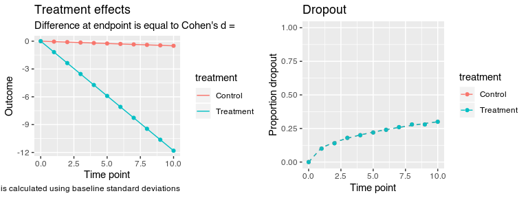

```r
plot(p)
```

And the power can be calculated using `get_power`.

```r
get_power(p)
```

```
##
##      Power Analyis for Longitudinal Linear Mixed-Effects Models (three-level)
##                   with missing data and unbalanced designs
##
##               n1 = 11
##               n2 = 10 x 5 (treatment)
##                    10 x 5 (control)
##               n3 = 5      (treatment)
##                    5      (control)
##                    10     (total)
##          total_n = 50     (control)
##                    50     (treatment)
##                    100    (total)
##          dropout =  0,  1,  2,  3,  4,  5,  6,  7,  8,  9, 10 (time)
##                     0, 11, 15, 18, 20, 22, 24, 26, 27, 29, 30 (%, control)
##                     0, 11, 15, 18, 20, 22, 24, 26, 27, 29, 30 (%, treatment)
## icc_pre_subjects = 0.5
## icc_pre_clusters = 0
##        icc_slope = 0.05
##        var_ratio = 0.02
##      effect_size = -0.8 (Cohen's d [SD: pretest_SD])
##               df = 8
##            alpha = 0.05
##            power = 63%
```

## Different dropout patterns per treatment group

The helper function `per_treatment` can also be used to define different dropout patterns per treatment arm.

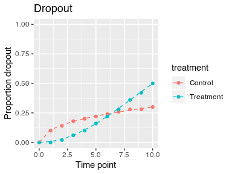

```r
d <- per_treatment(control = dropout_weibull(proportion = 0.3,
                                                rate = 1/2),
                   treatment = dropout_weibull(proportion = 0.5,
                                                rate = 2))

p2 <- study_parameters(n1 = 11,
                      n2 = 10,
                      n3 = 5,
                      icc_pre_subject = 0.5,
                      icc_pre_cluster = 0,
                      var_ratio = 0.02,
                      icc_slope = 0.05,
                      dropout = d,
                      fixed_slope = -0.5/10,
                      effect_size = cohend(-0.8,
                                           standardizer = "pretest_SD"))

plot(p2, type = "dropout")
```

# The design effect and Type I errors if clustering is ignored

You might be interested in calculation the *design effect*. The `get_DEFT`-function will calculate the design effect for the standard error of the `time:treatment`-interaction. DEFT tells you how many times larger the standard errors from the misspecified model should be. It will also report the approximate Type I error if the random slope at the third level is omitted. Here’s an example that investigates the impact of increasing cluster sizes on the DEFT.

```r
p2 <- study_parameters(n1 = 11,
                      n2 = c(5, 10, 15, 20, 30),
                      n3 = 5,
                      icc_pre_subject = 0.5,
                      icc_pre_cluster = 0,
                      var_ratio = 0.02,
                      icc_slope = 0.05,
                      dropout = dropout_weibull(proportion = 0.3,
                                                rate = 1/2),
                      fixed_slope = -0.5/10,
                      effect_size = cohend(-0.8,
                                           standardizer = "pretest_SD"))
get_DEFT(p2)
```

```
##   icc_slope var_ratio     DEFT approx_type1
## 1      0.05      0.02 1.050624   0.06210795
## 2      0.05      0.02 1.110058   0.07745618
## 3      0.05      0.02 1.166994   0.09305509
## 4      0.05      0.02 1.222293   0.10882116
## 5      0.05      0.02 1.325559   0.13924877
```

We can see that the design effect increases with more subjects per cluster. Even when only 5 % of the slope variance is at the cluster level, Type I errors can be considerably inflated if the random slope at the third-level is ignored.

# References

Raudenbush, S. W., and L. Xiao-Feng. 2001. “Effects of Study Duration, Frequency of Observation, and Sample Size on Power in Studies of Group Differences in Polynomial Change.” *Psychological Methods* 6 (4): 387–401.